# Manager Efficiency

2024-12-30

## Manager Efficiency at Setting Lineups

Matt Brown was the most efficient manager this year: his lineups achieved a **89.8%** of possible points! Greg was the leas efficient manager with his lineups recording just 82.7% of the what the optimal lineup would have scored.

If we were all perfect managers and set the optimal lineup each week, Nick would have had the highest point total for the season with an average of just over **150** points per week!

Tyler had the weakest roster of the league. Even if he started the optimal lineup each week, he would have barely cracked top 5 in points scored.

Tom’s roster wasn’t much better, but may have been able to pass Tyler and avoid the lowest points scored with some better lineup management.

Here’s how to read the chart below:

- solid dot is the actual points scored
- empty dot is points that would have been scored with the optimal lineup
- percentage label is your efficiency, or what percent of possible points you scored.

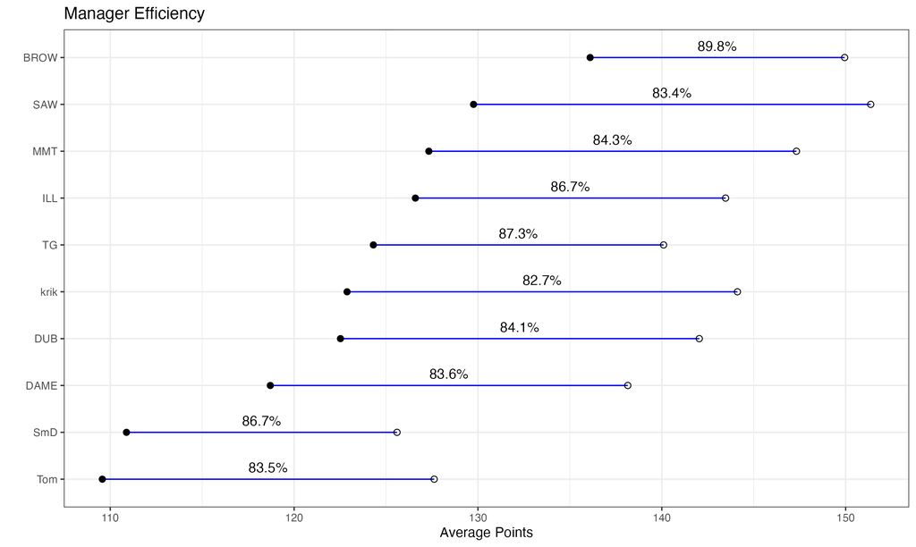